# CSCI E-63C Week 10 Problem Set

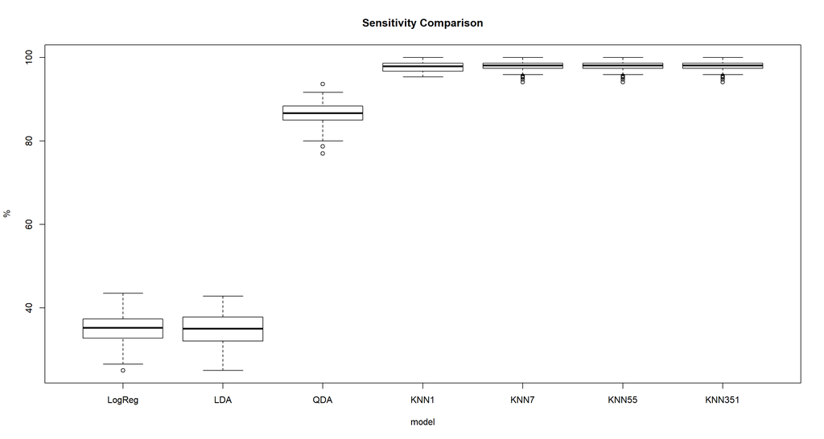

```r
boxplot(sensitivity, ylab = "%", xlab = "model", main = "Sensitivity Comparison")
```

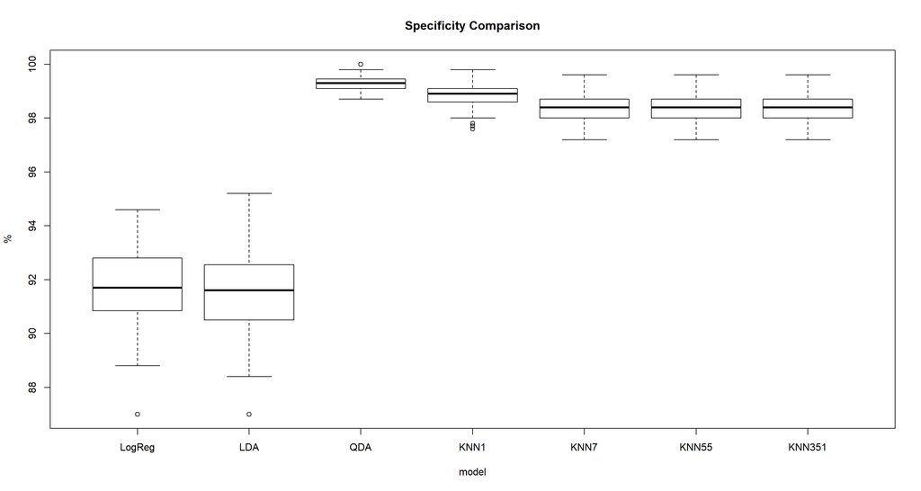

```r
boxplot(specificity, ylab = "%", xlab = "model", main = "Specificity Comparison")
```

The data was resampled 100 times using 30% of the data as a test data set and 70% as a training data set.

The test error rates for logistic regression and LDA are unacceptably high. These same models are had low sensitivity which means it often does not detect when a phone is at location 3. They also have a lower specificity with a wide variance. Although the range of values is still in the high 80’s to mid-90’s this indicates these models are inconsisent and poor in comparison to the other models by determining too many phones are at location 3 when they truly are not.

QDA had the highest specificity so it was very good at not falsey identifying a phone at location 3 when it was indeed not there. Its sensitivity and test error rates were also markedly better than LDA and logistic regression but still not as good as any of the KNN models.

The test error rates for the KNN methods were all very low and very tight. The KNN with n=1 had a slightly lower test error rate than the others.

The specificity of the KNN with n=1 performed higher than the other KNN models but not as good as the QDA model. The specificity of the KNN with n=1 also had a tighter variance and is therefore more consistent in its predictions.

In summary, depending on what the end goal of the predicition will be used for and what the stakeholder’s needs are, there are several models that could be chosen. If the goal is to be right the absolute most on any one guess, then the KNN with n=1 model is the right tool. If the goal is to very accurately and consistently know if a phone is truly in location 3 than KNN with n=7 is the best choice. If the goal is to minimize the number of times the model incorrectly states a phone is at location 3 when indeed it is not, then the QDA model is optimal. If there are multiple stakeholders with multiple points of view looking to compromise then the KNN wiht n=1 does a good job balancing the three statistics.

# Extra 5 points problem: naive Bayes classifier

Fit naive Bayes classifier (see lecture slides for examples of using `naiveBayes` function from package `e1071`) to the WiFi localization dataset with binary (location=3 or not) outcome and assess its performance on test data by resampling along with logistic regression, LDA, QDA and KNN in the Problem 4 above.

# Extra 10 points problem: interaction terms in logistic regression

Add pairwise interaction terms to the logistic regression model fit in the Problem 1 above and evaluate impact of their addition on training **and** test error. You can add all pairwise interaction terms or a subset of them, in which case the rationale behind selecting such a subset has to be described in your solution.